# Práctica 4-II - Ejercicio 6

Una compañía de equipos de ski desea relacionar las:

- ventas trimestrales: V
- con el ingreso personal disponible: PDI

Ambas variables se miden en billones de dólares, y los datos correspondientes se presentan en el archivo ski.xls.

# Item a y b

**Ajuste el modelo:**

$$V_t = \beta_0 + \beta_1 PDI_t + u_t$$
aplique el test de Durbin–Watson. ¿Cuál es su conclusión?.

Idea: realizar un ajuste, estudiar el gráfico de la recta ajustada y el de los residuos en función del número de observación.

### Ajuste

```r
df = read_excel("~/code/Modelo_Lineal_2019/ejercicios/Ski.xls")
reg = lm(Ventas~PDI, data=df)
summary(reg)
```

```
##
## Call:
## lm(formula = Ventas ~ PDI, data = df)
##
## Residuals:
##    Min     1Q Median     3Q    Max
## -5.229 -2.686  0.554  2.728  4.454
##
## Coefficients:
##             Estimate Std. Error t value Pr(>|t|)
## (Intercept) 12.39215    2.53942    4.88 1.93e-05 ***
## PDI          0.19791    0.01602   12.35 7.09e-15 ***
## ---
## Signif. codes:  0 '***' 0.001 '**' 0.01 '*' 0.05 '.' 0.1 ' ' 1
##
## Residual standard error: 3.019 on 38 degrees of freedom
## Multiple R-squared:  0.8006, Adjusted R-squared:  0.7953
## F-statistic: 152.5 on 1 and 38 DF,  p-value: 7.089e-15
```

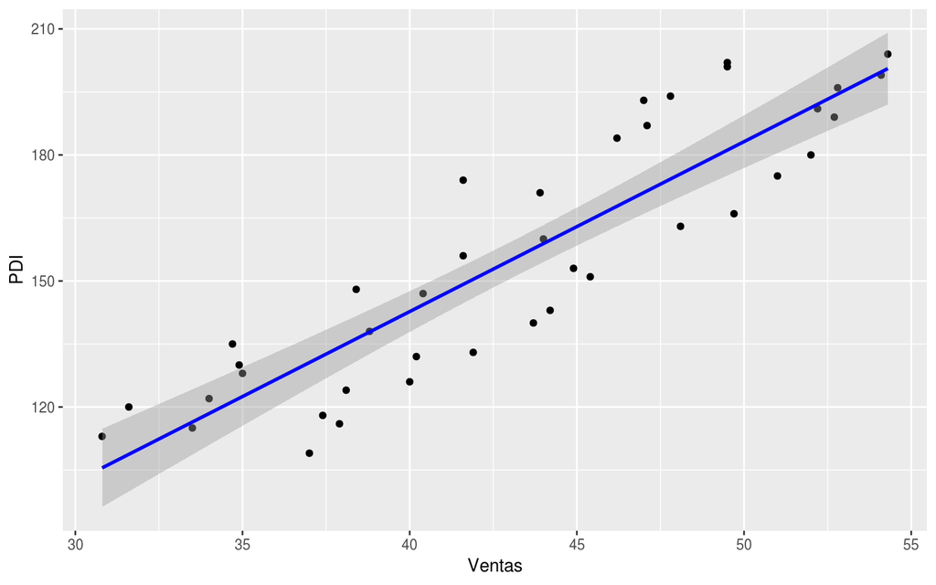

```r
ggplot(df, aes(x=Ventas, y=PDI)) + geom_point() + stat_smooth(method = "lm", col = "blue")
```

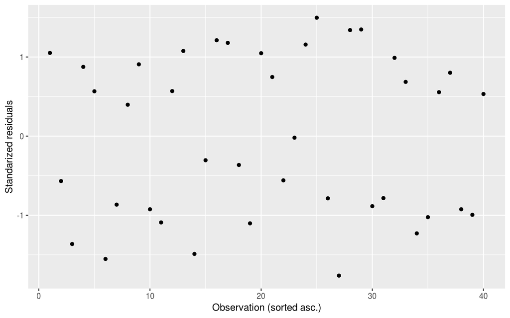

```r
ggplot(df, aes(x=1:nrow(df), y=rstandard(reg))) + geom_point() + xlab('Observation (sorted asc.)') +
ylab("Standarized residuals")
```

```r
dw = calculate_durbin_watson_statistic(reg$residuals)
rho_hat = 1 -dw/2
```

- El coeficiente de determinación $R^2 \approx 0.8$ nos indica que el ajuste no es tan bueno.
- Sospecho que este modelo necesita una variable categórica para ajustar dos rectas.
- La regresión es significativa
- Los residuos tienen cierta estructura, pero no hay evidencia de autocorrelación en los residuos pues:

$$dw \approx 1.98 \quad \Rightarrow \quad \hat{\rho} \approx 0.009,$$

# Item c

### Variables dummies

Asumo que las filas del set de datos están ordenadas por trimestre, entonces puedo hacer:

```r
df_trimestres = data.frame(trimestre=factor(rep(seq(4), 10)))
df_trimestres = fastDummies::dummy_cols(df_trimestres, select_columns = "trimestre")
df = cbind(df, t1=df_trimestres$trimestre_1, t2=df_trimestres$trimestre_2, t3=df_trimestres$trimestre_3)
head(df)
```

```
##   Ventas PDI t1 t2 t3
## 1   37.0 109  1  0  0
## 2   33.5 115  0  1  0
## 3   30.8 113  0  0  1
## 4   37.9 116  0  0  0
## 5   37.4 118  1  0  0
## 6   31.6 120  0  1  0
```

Ajusto el modelo con las variables dummies

```r
reg2 = lm(Ventas~., data=df)
summary(reg2)
```

```
##
## Call:
## lm(formula = Ventas ~ ., data = df)
##
## Residuals:
##      Min       1Q   Median       3Q      Max
## -2.51356 -0.86028  0.03654  0.67965  2.67306
##
## Coefficients:
##             Estimate Std. Error t value Pr(>|t|)
## (Intercept) 14.77202    1.05058  14.061 5.78e-16 ***
## PDI          0.19904    0.00619  32.155  < 2e-16 ***
## t1           0.35312    0.52150   0.677    0.503
## t2          -5.28382    0.52018 -10.158 5.62e-12 ***
## t3          -5.29210    0.51977 -10.182 5.28e-12 ***
## ---
## Signif. codes:  0 '***' 0.001 '**' 0.01 '*' 0.05 '.' 0.1 ' ' 1
##
## Residual standard error: 1.162 on 35 degrees of freedom
## Multiple R-squared:  0.9728, Adjusted R-squared:  0.9697
## F-statistic:   313 on 4 and 35 DF,  p-value: < 2.2e-16
```

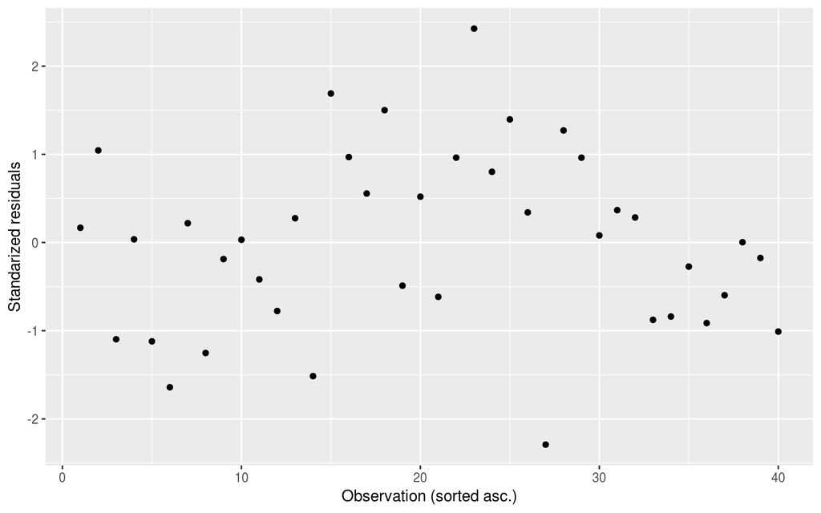

```r
ggplot(df, aes(x=1:nrow(df), y=rstandard(reg2))) + geom_point() + xlab('Observation (sorted asc.)') +
ylab("Standarized residuals")
```

```r
dw2 = calculate_durbin_watson_statistic(reg2$residuals)
rho_hat2 = 1 - dw2/2
```

- La distribución de los residuos cambió. Ahora no se distinguen dos grupos separados sino uno solo.
- La autocorrelación de los residuos aumentó $dw \approx 1.82 \quad \Rightarrow \quad \hat{\rho} \approx 0.089,$, pero sigue siendo despreciable.

# Item d

**Utilice una sola variable dummy que valga 1 para el primer y el cuarto trimestre y 0 para el segundo y el tercero y repita el análisis realizado en c) con esta nueva variable dummy reemplazando a las 3 utilizadas en dicho ı́tem.**

¿Cuál cree que es la razón que justifica la definición de esta nueva variable dummy?

En el Item a y b apunté que quizá fuera necesario agregar una variable dummy para mejorar la calidad del ajuste. Esto se desprendía del gráfico del ajuste simple y de la estructura del gráfico de residuos. Agreguemos una variable dummy:

```r
df = cbind(df, t14=1 - (df$t2 + df$t3))
reg3 = lm(Ventas~PDI + t14, data=df)
summary(reg3)
```

```
##
## Call:
## lm(formula = Ventas ~ PDI + t14, data = df)
##
## Residuals:
##      Min       1Q   Median       3Q      Max
## -2.51118 -0.78640  0.02632  0.72842  2.67040
##
## Coefficients:
##             Estimate Std. Error t value Pr(>|t|)
## (Intercept) 9.540202   0.974825   9.787 8.23e-12 ***
## PDI         0.198684   0.006036  32.915  < 2e-16 ***
## t14         5.464342   0.359682  15.192  < 2e-16 ***
## ---
## Signif. codes:  0 '***' 0.001 '**' 0.01 '*' 0.05 '.' 0.1 ' ' 1
##
## Residual standard error: 1.137 on 37 degrees of freedom
## Multiple R-squared:  0.9724, Adjusted R-squared:  0.971
## F-statistic: 652.9 on 2 and 37 DF,  p-value: < 2.2e-16
```

```r
dw3 = calculate_durbin_watson_statistic(reg3$residuals)
rho_hat3 = 1 - dw3/2
```

En la figura se puede observar que los residuos no tienen una estructura evidente.

En la siguiente tabla resumimos algunas medidas de los tres ajustes realizados. Se puede observar que los ajustes que incluyen variables dummies tienen un mejor coeficiente de determinación y es muy parecido. La significancia de la regresión, representada por el valor del estadístico F es mucho mayor en el ajuste que utiliza sólo una dummy.

Entonces parece no ser necesario utilizar 3 dummies sino sólamente 1.

| Covariables | F | $R^2$ | Durbin Watson | $\hat{\rho}$ |
| --- | --- | --- | --- | --- |
| PDI | 152.5 | $\approx 0.8$ | 1.98 | 0.009 |
| PDI + 3 dummies | 313 | $\approx 0.973$ | 1.82 | 0.089 |
| PDI + 1 dummy | 652.9 | $\approx 0.972$ | 1.83 | 0.084 |

# Item e

**Analice la independencia de los residuos obtenidos con el ajuste del ı́tem d) y aplique el test de Shapiro Wilk para estudiar su normalidad.**

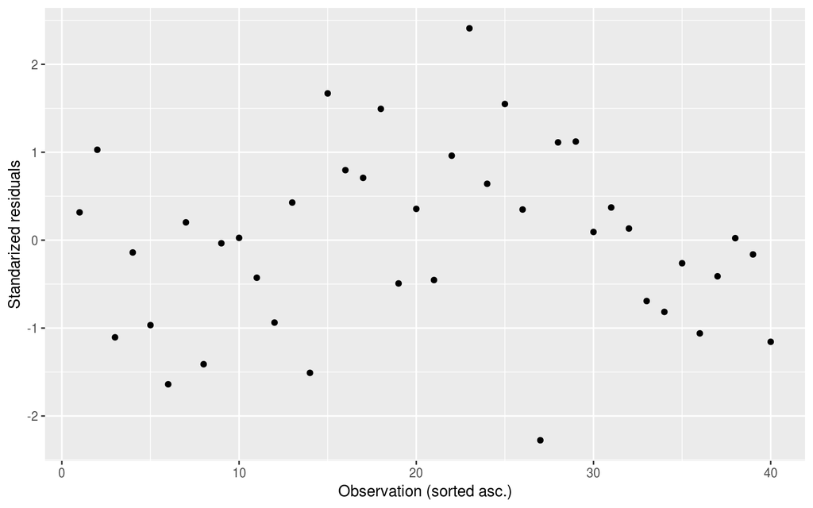

```r
ggplot(df, aes(x=1:nrow(df), y=rstandard(reg3))) + geom_point() + xlab('Observation (sorted asc.)') +
ylab("Standarized residuals")
```

### Test de Shapiro-Wilk

Corremos un test de shapiro y realizamos un qq-plot con los residuos estandarizados

```r
shapiro.test(reg3$residuals)
```

```
##
##  Shapiro-Wilk normality test
##
## data:  reg3$residuals
## W = 0.99507, p-value = 0.9997
```

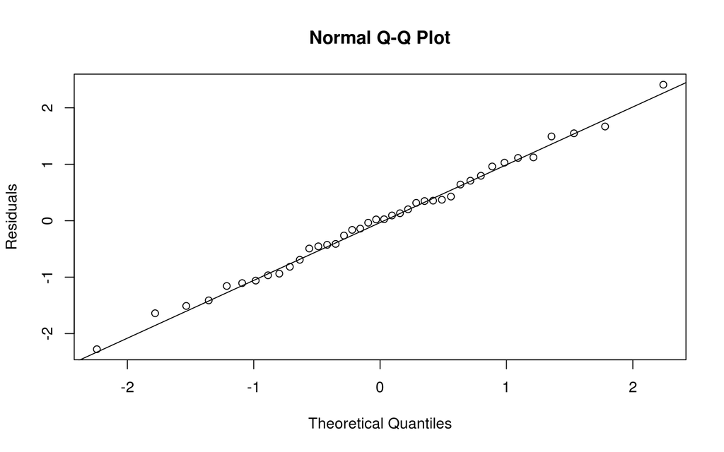

```r
qqnorm(rstandard(reg3), ylab="Residuals")
qqline(rstandard(reg3))
```

```r
cor(df$PDI, reg3$residuals)
```

```
## [1] 9.320229e-18
```

```r
cor(df$t14, reg3$residuals)
```

```
## [1] -3.203866e-17
```

Se desprende de la figura que los residuos estandarizados pueden considerarse normales. Además el test de Shapiro-Wilk arroja un p-valor de 0.9997.

Además la correlación de los residuos con las variables regresoras es aproximadamente cero. Esto indica nula dependencia lineal.

Mariano Barraco marianobarraco@gmail.com

2019-06-23